# DATA PROCESSES FINAL PROJECT (GROUP 3)

### Group Members

| Name | Github username |
| --- | --- |
| ANGULO MONTES LUIS EDUARDO | LuisEduardoAngulo |
| BORRERO GARCIA FRANCISCO | Macvayne |
| TAHIRI ALAOUI OUSSAMA | oussama-talaoui |

### Abstract

The aim of this project was to work with a “credit card default” dataset to classify if a person would fall or not in credit default considering demographic and banking characteristics.

For each model that we realized to answer our question, there were no significant differences between the models in terms of the performance measures. The first one was Decision Tree, the second one was Logistic and the last one was Neural Network.

### Introduction and Related Work

#### Motivation:

The motivation of this project was to ﬁnd a simple and an effective predictive model for the banks to determine if their customers could make the credit card payments on-time. The banks with the invent of credit card were more focused on the number of customers using their credit service but the drawback of them not being able to pay back the credit in time was an issue that soon followed, a system was in need to effectively decide the credit limit to be allowed to a person based on his previous credit history, concentrating on this issue we were motivated to consider various parameters such as sex, age , level of education along with customer details and the credit history of the past 6 months to give a reliable and effective prediction if a customer is able to pay the credit.

So, the main goal was to classify the instances of our dataset according to their demographic and banking features between two classes, to see if they belong or not to credit default.

#### Relevant Work:

- SR Islam, W Eberle, SK Ghafoor. (2018). “Credit default mining using combined machine learning and heuristic approach” Proceedings of the 2018 International Conference on Data Science, 16-22.
- Sharma, Sunakshi & Mehra, Vipul. (2018). Default Payment Analysis of Credit Card Clients. 10.13140/RG.2.2.31307.28967.
- Yeh, I. C., & Lien, C. H. (2009). The comparisons of data mining techniques for the predictive accuracy of probability of default of credit card clients. Expert Systems with Applications, 36(2), 2473-2480.
- https://www.researchgate.net/publication/326171439_Default_Payment_Analysis_of_Credit_Card_Clients
- https://ieeexplore.ieee.org/document/8776802

#### Exploratory Data Analysis:

- About The Dataset:

For this work, we used the “Taiwan’s credit card default clients” dataset. This one was taken from the UCI Machine Learning Repository and it is composed of 24 features and 30.000 instances. URL where dataset is from: [Dataset](https://www.kaggle.com/uciml/default-of-credit-card-clients-dataset)

Basically, it contains some demographic and banking information from credit cardholders of a bank in Taiwan for 2005. The features are described as follow:

| BAL | SEX | EDUCATION | MARRIAGE | AGE | RPSEP | RPAGO | RPJUL | RPJUN | RPMAY | RPABR | BILLSEP | BILLAGO | BILLJUL | BILLJUN | BILLMAY | BILLABR | PREPAYSEP | PREPAYAGO | PREPAYJUL | PREPAYJUN | PREPAYMAY | PREPAYABR | DEFAULT |
| --- | --- | --- | --- | --- | --- | --- | --- | --- | --- | --- | --- | --- | --- | --- | --- | --- | --- | --- | --- | --- | --- | --- | --- |
| 20000 | 2 | 2 | 1 | 24 | 2 | 2 | -1 | -1 | -2 | -2 | 3913 | 3102 | 689 | 0 | 0 | 0 | 0 | 689 | 0 | 0 | 0 | 0 | 1 |
| 120000 | 2 | 2 | 2 | 26 | -1 | 2 | 0 | 0 | 0 | 2 | 2682 | 1725 | 2682 | 3272 | 3455 | 3261 | 0 | 1000 | 1000 | 1000 | 0 | 2000 | 1 |
| 90000 | 2 | 2 | 2 | 34 | 0 | 0 | 0 | 0 | 0 | 0 | 29239 | 14027 | 13559 | 14331 | 14948 | 15549 | 1518 | 1500 | 1000 | 1000 | 1000 | 5000 | 0 |
| 50000 | 2 | 2 | 1 | 37 | 0 | 0 | 0 | 0 | 0 | 0 | 46990 | 48233 | 49291 | 28314 | 28959 | 29547 | 2000 | 2019 | 1200 | 1100 | 1069 | 1000 | 0 |
| 50000 | 1 | 2 | 1 | 57 | -1 | 0 | -1 | 0 | 0 | 0 | 8617 | 5670 | 35835 | 20940 | 19146 | 19131 | 2000 | 36681 | 10000 | 9000 | 689 | 679 | 0 |

The dimension of the dataset, the structure and number if missing values:

```
## [1] 30000    24
```

```
## Classes 'tbl_df', 'tbl' and 'data.frame':    30000 obs. of  24 variables:
##  $ BAL      : num  20000 120000 90000 50000 50000 50000 500000 100000 140000 20000 ...
##  $ SEX      : num  2 2 2 2 1 1 1 2 2 1 ...
##  $ EDUCATION: num  2 2 2 2 2 1 1 2 3 3 ...
##  $ MARRIAGE : num  1 2 2 1 1 2 2 2 1 2 ...
##  $ AGE      : num  24 26 34 37 57 37 29 23 28 35 ...
##  $ RPSEP    : num  2 -1 0 0 -1 0 0 0 0 -2 ...
##  $ RPAGO    : num  2 2 0 0 0 0 0 -1 0 -2 ...
##  $ RPJUL    : num  -1 0 0 0 -1 0 0 -1 2 -2 ...
##  $ RPJUN    : num  -1 0 0 0 0 0 0 0 0 -2 ...
##  $ RPMAY    : num  -2 0 0 0 0 0 0 0 0 -1 ...
##  $ RPABR    : num  -2 2 0 0 0 0 0 -1 0 -1 ...
##  $ BILLSEP  : num  3913 2682 29239 46990 8617 ...
##  $ BILLAGO  : num  3102 1725 14027 48233 5670 ...
##  $ BILLJUL  : num  689 2682 13559 49291 35835 ...
##  $ BILLJUN  : num  0 3272 14331 28314 20940 ...
##  $ BILLMAY  : num  0 3455 14948 28959 19146 ...
##  $ BILLABR  : num  0 3261 15549 29547 19131 ...
##  $ PREPAYSEP: num  0 0 1518 2000 2000 ...
##  $ PREPAYAGO: num  689 1000 1500 2019 36681 ...
##  $ PREPAYJUL: num  0 1000 1000 1200 10000 657 38000 0 432 0 ...
##  $ PREPAYJUN: num  0 1000 1000 1100 9000 ...
##  $ PREPAYMAY: num  0 0 1000 1069 689 ...
##  $ PREPAYABR: num  0 2000 5000 1000 679 ...
##  $ DEFAULT  : num  1 1 0 0 0 0 0 0 0 0 ...
```

```
## [1] 0
```

The dataset doesn’t not have any missing values.

#### Graphics:

Basic graphs to check the distribution of 3 features:

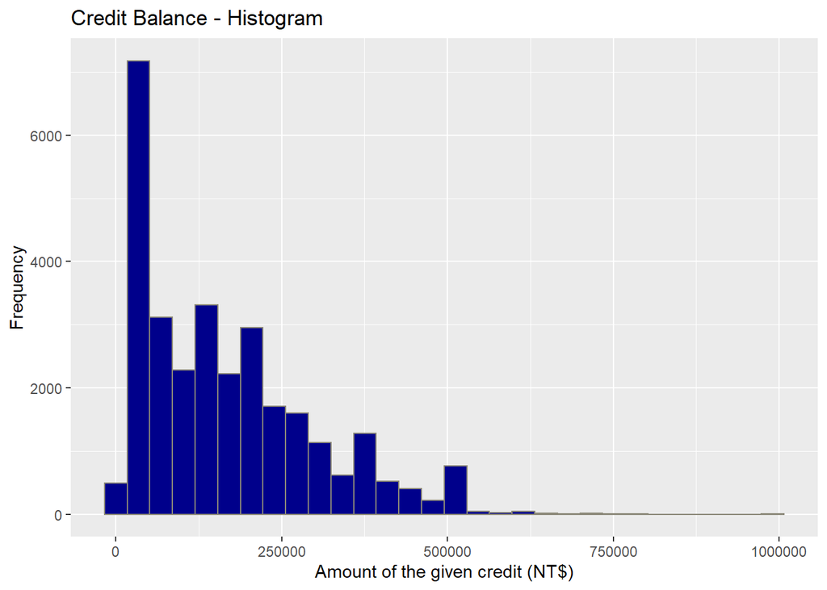

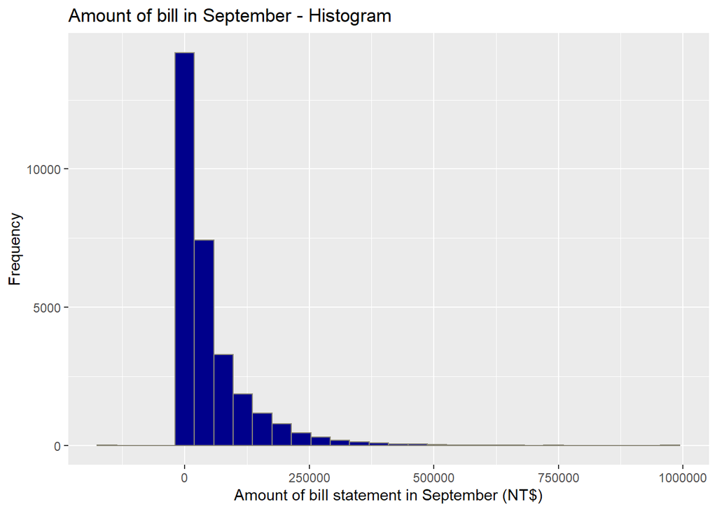

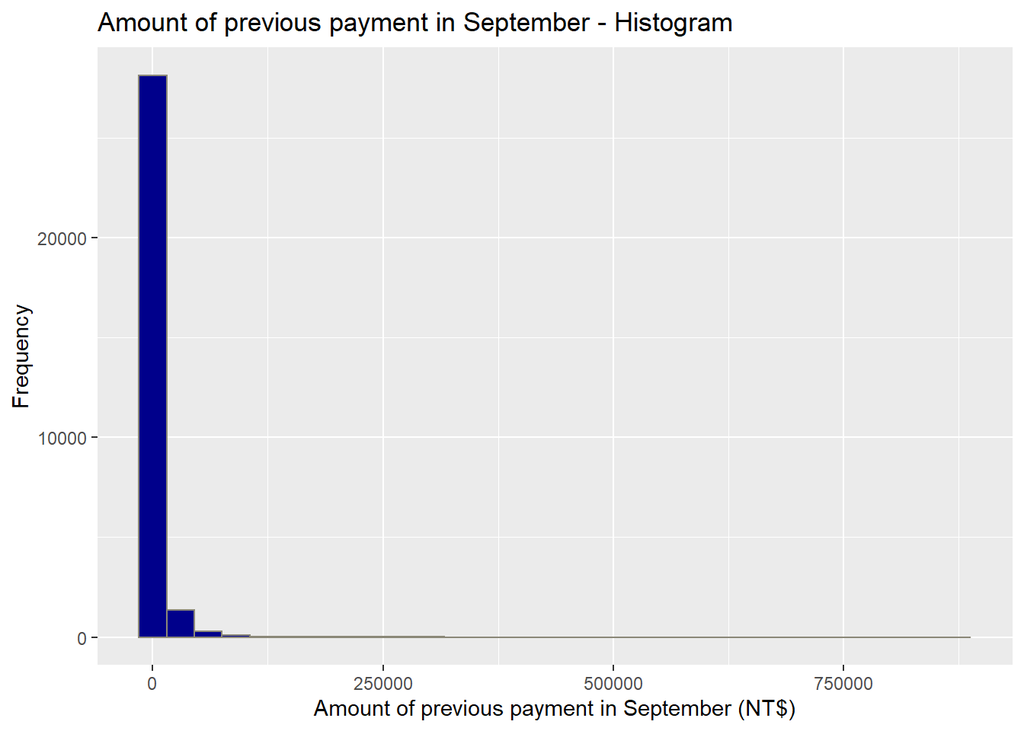

Most of the numerical type features present a positive skewness.

Let us go deeper to understand the behavior of the default payment regarding the balance in the account:

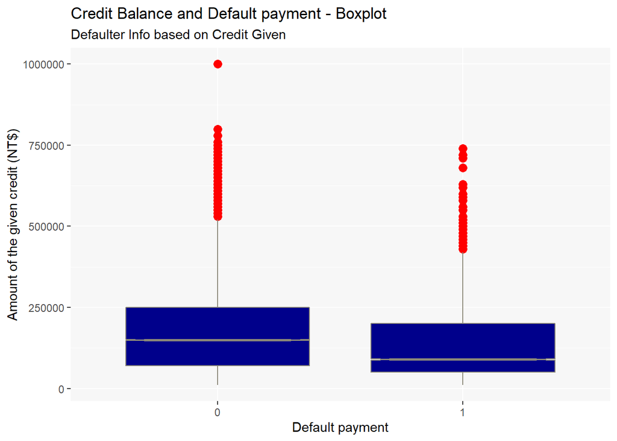

It seems that there is differences between the groups, the people with default tends to have a lower balance account. We must highlight the outlier.

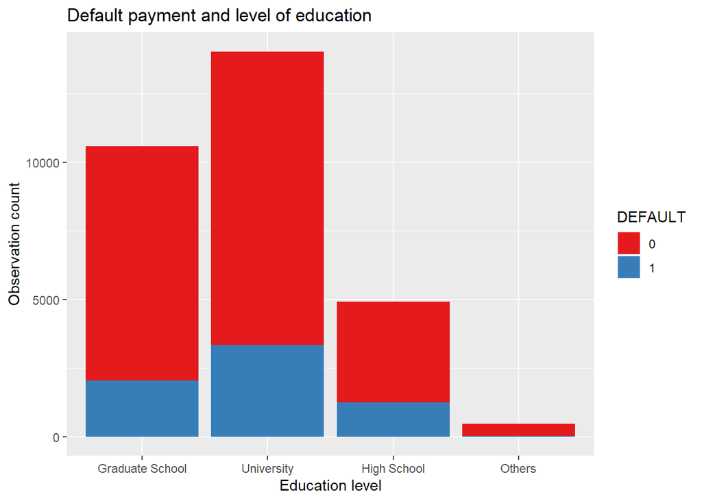

We can see that mostly university graduated people are the ones with more defaults.

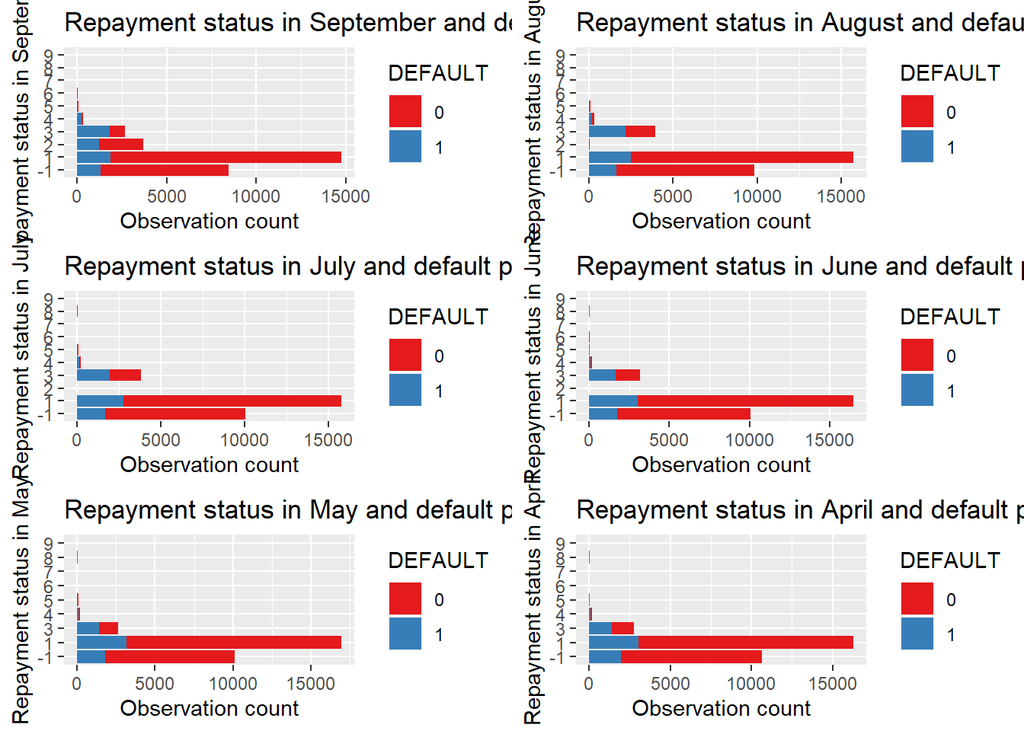

We can see that most of the people with default have payments delay for one or three months.

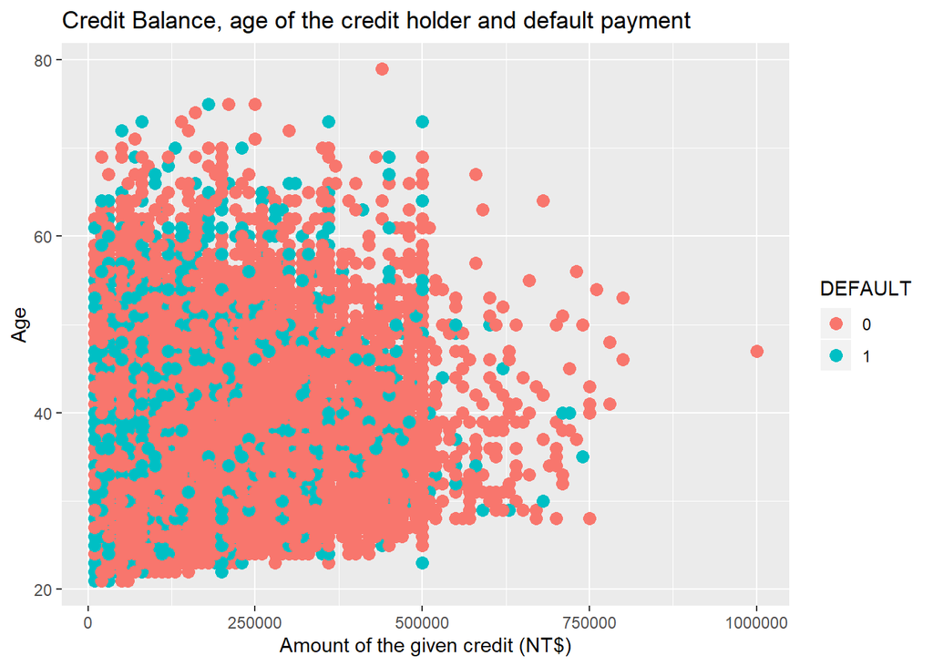

And finally, we can see that there is not a visible pattern between the age and balance amount, also it is no possible to establish a relation between this two and the default payment.

### Methods

The appropriate methods are employed to answer the question of interest, including:

- **Strength of relationships**:

All the work related to machine learning algorithms and data preparation was done using R software, basically, “mlr” package, and others.

As mentioned before, the dataset did not have any missing values, but the data wrangling and engineering was necessary because of the categorical features, as they did not appear as it was mentioned in the repository. Therefore, the first thing that we did was a dummy encoding for sex, education and marriage features, where the following levels were dropped in each one: men, other education, other marital status.

Furthermore, in the data exploration, we realized that the repayment status was not between the proper range (-1 to 9), it was slid one unit (going for -2 to 8); thus, we added one unit to the scale. Regarding this feature, we chose not to encode it as a dummy due to it being ordinal, so it was used as it is.

The proper explanatory data analysis was conducted, checking correlations, skewness, kurtosis, normality distribution and so on; we found issues in the dataset with these measures. For instance, most of the numerical type features presented positive skewness. Moreover, we checked for potential outliers, scaling the features in a range from 0 to a 1, and dropping the ones that showed values higher than 3 (Euclidean distance threshold). The dataset was reduced to 29,265 instances, so we dropped around 735 instances that were potential outliers.

- **Prediction**:

Once the dataset was split, we proceeded to scale the features because some of them were in different units of measurement. To fulfill this task, we used the min-max scaling function. Afterward, a statistical summary was applied to check the results. We realized that for the machine learning algorithms deployment, we would have some trouble with predictions because of the classes of our label feature. To solve this unbalance data issue, we performed a data balance process to avoid that in our prediction, the model will be tempted to misclassify the minority class. In general, machine learning algorithms tends to follow the majority, so they will perform well with the most common class and not that good with the uncommon one.

It is important to remark that for resampling (assessed of the algorithms) we used repeated cross-validation, setting the parameters in 3 folds and 2 repetitions.

### Results

The summary of the data we used for training:

```
##       BAL              AGE            RPSEP             RPAGO
##  Min.   : 10000   Min.   :21.00   Min.   :-1.0000   Min.   :-1.0000
##  1st Qu.: 50000   1st Qu.:28.00   1st Qu.:-1.0000   1st Qu.:-1.0000
##  Median :140000   Median :34.00   Median : 1.0000   Median : 1.0000
##  Mean   :162439   Mean   :35.44   Mean   : 0.7825   Mean   : 0.6509
##  3rd Qu.:230000   3rd Qu.:41.00   3rd Qu.: 1.0000   3rd Qu.: 1.0000
##  Max.   :800000   Max.   :75.00   Max.   : 9.0000   Max.   : 9.0000
##      RPJUL             RPJUN             RPMAY             RPABR
##  Min.   :-1.0000   Min.   :-1.0000   Min.   :-1.0000   Min.   :-1.0000
##  1st Qu.:-1.0000   1st Qu.:-1.0000   1st Qu.:-1.0000   1st Qu.:-1.0000
##  Median : 1.0000   Median : 1.0000   Median : 1.0000   Median : 1.0000
##  Mean   : 0.6196   Mean   : 0.5741   Mean   : 0.5334   Mean   : 0.5003
##  3rd Qu.: 1.0000   3rd Qu.: 1.0000   3rd Qu.: 1.0000   3rd Qu.: 1.0000
##  Max.   : 9.0000   Max.   : 9.0000   Max.   : 9.0000   Max.   : 9.0000
##     BILLSEP           BILLAGO          BILLJUL           BILLJUN
##  Min.   :-154973   Min.   :-69777   Min.   :-157264   Min.   :-170000
##  1st Qu.:   3324   1st Qu.:  2774   1st Qu.:   2500   1st Qu.:   2176
##  Median :  20947   Median : 20129   Median :  19402   Median :  18416
##  Mean   :  45138   Mean   : 43096   Mean   :  40805   Mean   :  37195
##  3rd Qu.:  61196   3rd Qu.: 58927   3rd Qu.:  55234   3rd Qu.:  50306
##  Max.   : 613860   Max.   :535509   Max.   : 855086   Max.   : 530672
##     BILLMAY          BILLABR         PREPAYSEP          PREPAYAGO
##  Min.   :-81334   Min.   :-94625   Min.   :     0.0   Min.   :      0
##  1st Qu.:  1618   1st Qu.:  1150   1st Qu.:   893.8   1st Qu.:    780
##  Median : 17259   Median : 16071   Median :  2056.5   Median :   2000
##  Mean   : 34253   Mean   : 33044   Mean   :  5264.7   Mean   :   5393
##  3rd Qu.: 47769   3rd Qu.: 46661   3rd Qu.:  5000.0   3rd Qu.:   5000
##  Max.   :222558   Max.   :217475   Max.   :493358.0   Max.   :1227082
##    PREPAYJUL        PREPAYJUN        PREPAYMAY        PREPAYABR
##  Min.   :     0   Min.   :     0   Min.   :     0   Min.   :     0.0
##  1st Qu.:   390   1st Qu.:   247   1st Qu.:   200   1st Qu.:    80.8
##  Median :  1746   Median :  1496   Median :  1500   Median :  1472.0
##  Mean   :  4801   Mean   :  4348   Mean   :  4380   Mean   :  4890.2
##  3rd Qu.:  4180   3rd Qu.:  3904   3rd Qu.:  4000   3rd Qu.:  3936.0
##  Max.   :417588   Max.   :497000   Max.   :331788   Max.   :377000.0
##  DEFAULT       MUJER           PREGRADO         HSCHOOL
##  0:18268   Min.   :0.0000   Min.   :0.0000   Min.   :0.0000
##  1: 5144   1st Qu.:0.0000   1st Qu.:0.0000   1st Qu.:0.0000
##            Median :1.0000   Median :0.0000   Median :0.0000
##            Mean   :0.6063   Mean   :0.4665   Mean   :0.1665
##            3rd Qu.:1.0000   3rd Qu.:1.0000   3rd Qu.:0.0000
##            Max.   :1.0000   Max.   :1.0000   Max.   :1.0000
##     POSGRADO          SINGLE          MARRIED
##  Min.   :0.0000   Min.   :0.0000   Min.   :0.0000
##  1st Qu.:0.0000   1st Qu.:0.0000   1st Qu.:0.0000
##  Median :0.0000   Median :1.0000   Median :0.0000
##  Mean   :0.3513   Mean   :0.5335   Mean   :0.4538
##  3rd Qu.:1.0000   3rd Qu.:1.0000   3rd Qu.:1.0000
##  Max.   :1.0000   Max.   :1.0000   Max.   :1.0000
```

- **Decision Tree**:

As its name suggests, this algorithm follows a tree structure to predict a class, where each tree has its root node (a relevant feature to predict the class), leaf nodes (following features) and branches (output of the test). Works by partitioning the feature space into a number of smaller scenarios with similar response values using a set of splitting rules. The segmentation process is typically carried out using only one explanatory variable at a time.

Train:

```
## n= 25720
##
## node), split, n, loss, yval, (yprob)
##       * denotes terminal node
##
##  1) root 25720 10288 0 (0.6000000 0.4000000)
##    2) X.RPSEP< 0.3001086 21533  6678 0 (0.6898714 0.3101286)
##      4) X.RPSEP< 0.2001162 18047  4846 0 (0.7314789 0.2685211) *
##      5) X.RPSEP>=0.2001162 3486  1654 1 (0.4744693 0.5255307)
##       10) X.RPSEP>=0.2998721 3269  1615 0 (0.5059651 0.4940349)
##         20) X.RPABR< 0.2027987 2690  1224 0 (0.5449814 0.4550186) *
##         21) X.RPABR>=0.2027987 579   188 1 (0.3246978 0.6753022) *
##       11) X.RPSEP< 0.2998721 217     0 1 (0.0000000 1.0000000) *
##    3) X.RPSEP>=0.3001086 4187   577 1 (0.1378075 0.8621925) *
```

Prediction:

```
##       id truth response
## 9470   1     0        0
## 8225   2     1        0
## 3838   3     1        0
## 22921  4     0        0
## 43941  5     1        1
## 13149  6     1        0
```

```
##         predicted
## true         0    1 -err.-
##   0      14667  765    765
##   1       6070 4218   6070
##   -err.-  6070  765   6835
```

Performance:

[output not shown]

Resampling:

```
## Resampling: repeated cross-validation
```

```
## Measures:             acc       mmce      kappa
```

```
## [Resample] iter 1:    0.7349819 0.2650181 0.4088408
```

```
## [Resample] iter 2:    0.7341964 0.2658036 0.3967129
```

```
## [Resample] iter 3:    0.7303161 0.2696839 0.3864899
```

```
## [Resample] iter 4:    0.7385979 0.2614021 0.4040967
```

```
## [Resample] iter 5:    0.7221509 0.2778491 0.3810572
```

```
## [Resample] iter 6:    0.7213669 0.2786331 0.3932180
```

```
## Aggregated Result: acc.test.mean=0.7302684,mmce.test.mean=0.2697316,kappa.test.mean=0.3950693
```

```
##   acc.test.mean  mmce.test.mean kappa.test.mean
##       0.7302684       0.2697316       0.3950693
```

Here is a graph of the generated tree:

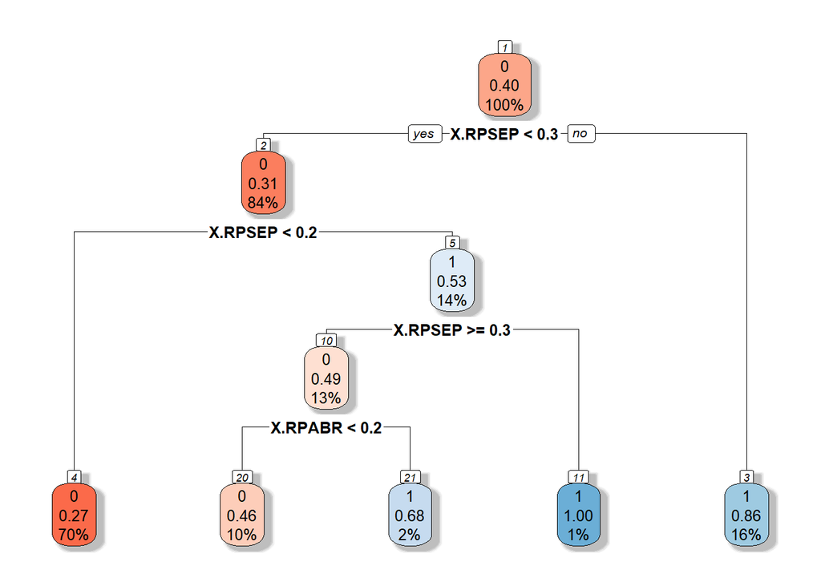

For our data, the algorithm applied for building the tree used some of the available features, but the most relevant ones were X.RPSEP and X.RPABR. Thus, according to this algorithm, the possibility of falling in credit default will be associated with the repayment status in September and the repayment status in April.

- **Logistic**:

According to I-Chen & Chen-hiu “logistic regression is used for binary classification; problems that are confined to two classes, basically, a logistic regression model specifies that an appropriate function of the fitted probability of the event is a linear function of the observed values of the available explanatory variables”.

Train:

```
##
## Call:
## stats::glm(formula = f, family = "binomial", data = getTaskData(.task,
##     .subset), weights = .weights, model = FALSE)
##
## Deviance Residuals:
##     Min       1Q   Median       3Q      Max
## -2.9076  -0.9852  -0.6382   1.0463   3.5039
##
## Coefficients:
##              Estimate Std. Error z value Pr(>|z|)
## (Intercept)  -1.40193    0.26714  -5.248 1.54e-07 ***
## X.BAL        -0.65926    0.11663  -5.653 1.58e-08 ***
## X.AGE         0.26567    0.09490   2.800 0.005117 **
## X.RPSEP       3.68314    0.13680  26.924  < 2e-16 ***
## X.RPAGO       1.03706    0.16886   6.142 8.16e-10 ***
## X.RPJUL       0.65945    0.18877   3.493 0.000477 ***
## X.RPJUN       0.02955    0.20711   0.143 0.886544
## X.RPMAY       0.67855    0.21982   3.087 0.002023 **
## X.RPABR      -0.39438    0.18910  -2.086 0.037019 *
## X.BILLSEP    -7.43172    0.91292  -8.141 3.93e-16 ***
## X.BILLAGO     3.60136    0.94053   3.829 0.000129 ***
## X.BILLJUL     1.31569    1.35524   0.971 0.331642
## X.BILLJUN    -0.12041    1.02629  -0.117 0.906600
## X.BILLMAY    -1.72140    0.60476  -2.846 0.004422 **
## X.BILLABR     1.81866    0.50585   3.595 0.000324 ***
## X.PREPAYSEP  -9.91466    1.19923  -8.267  < 2e-16 ***
## X.PREPAYAGO -15.07865    2.77389  -5.436 5.45e-08 ***
## X.PREPAYJUL  -3.40851    0.85059  -4.007 6.14e-05 ***
## X.PREPAYJUN  -2.41929    0.99616  -2.429 0.015157 *
## X.PREPAYMAY  -3.49443    0.72576  -4.815 1.47e-06 ***
## X.PREPAYABR  -0.90553    0.51935  -1.744 0.081232 .
## X.MUJER      -0.12676    0.02843  -4.458 8.26e-06 ***
## X.PREGRADO    1.07060    0.16067   6.663 2.68e-11 ***
## X.HSCHOOL     1.06930    0.16293   6.563 5.28e-11 ***
## X.POSGRADO    1.22049    0.16144   7.560 4.03e-14 ***
## X.SINGLE     -0.03952    0.12046  -0.328 0.742891
## X.MARRIED     0.17374    0.11906   1.459 0.144491
## ---
## Signif. codes:  0 '***' 0.001 '**' 0.01 '*' 0.05 '.' 0.1 ' ' 1
##
## (Dispersion parameter for binomial family taken to be 1)
##
##     Null deviance: 34620  on 25719  degrees of freedom
## Residual deviance: 30527  on 25693  degrees of freedom
## AIC: 30581
##
## Number of Fisher Scoring iterations: 5
```

Prediction:

```
##         predicted
## true         0    1 -err.-
##   0      13444 1988   1988
##   1       5243 5045   5243
##   -err.-  5243 1988   7231
```

Performance:

```
##       acc      mmce     kappa
## 0.7188569 0.2811431 0.3816804
```

Resampling:

```
## Resampling: repeated cross-validation
```

```
## Measures:             acc       mmce      kappa
```

```
## [Resample] iter 1:    0.7141358 0.2858642 0.3714065
```

```
## [Resample] iter 2:    0.7200513 0.2799487 0.3828601
```

```
## [Resample] iter 3:    0.7198180 0.2801820 0.3852551
```

```
## [Resample] iter 4:    0.7249504 0.2750496 0.3952155
```

```
## [Resample] iter 5:    0.7159687 0.2840313 0.3754344
```

```
## [Resample] iter 6:    0.7175181 0.2824819 0.3789394
```

```
## Aggregated Result: acc.test.mean=0.7187404,mmce.test.mean=0.2812596,kappa.test.mean=0.3815185
```

```
##   acc.test.mean  mmce.test.mean kappa.test.mean
##       0.7187404       0.2812596       0.3815185
```

For the logistic regression output we are going to focus our attention on the mean misclassification error (MMCE), this performance measure evaluates the number of the wrong classifications from the total input of the training set (in this case). The objective in a machine learning project is to minimize it; in our logistic model the mmce was 28 %, that means that this algorithm misclassified 28 % of the instances according to the observed class.

- **Neural Network**:

ANN are inspired by the way the human brain works, particularly, on the biological neuron structure. The approach holds all its power in a neuron, which is the central unit and the one in charge of the computations; thus, it receives features as inputs and then operates a function of the weighted sum of these plus the bias to generate an output. Essentially, the prediction of the class it’s done by a learning process that is based on examples.

Learner:

```
##            Type len    Def      Constr Req Tunable Trafo
## size    integer   -      3    0 to Inf   -    TRUE     -
## maxit   integer   -    100    1 to Inf   -    TRUE     -
## skip    logical   -  FALSE           -   -    TRUE     -
## rang    numeric   -    0.7 -Inf to Inf   -    TRUE     -
## decay   numeric   -      0 -Inf to Inf   -    TRUE     -
## Hess    logical   -  FALSE           -   -    TRUE     -
## trace   logical   -   TRUE           -   -   FALSE     -
## MaxNWts integer   -   1000    1 to Inf   -   FALSE     -
## abstol  numeric   - 0.0001 -Inf to Inf   -    TRUE     -
## reltol  numeric   -  1e-08 -Inf to Inf   -    TRUE     -
```

Train:

```
## a 26-3-1 network with 85 weights
## inputs: X.BAL X.AGE X.RPSEP X.RPAGO X.RPJUL X.RPJUN X.RPMAY X.RPABR X.BILLSEP X.BILLAGO X.BILLJUL X.BILLJUN X.BILLMAY X.BILLABR X.PREPAYSEP X.PREPAYAGO X.PREPAYJUL X.PREPAYJUN X.PREPAYMAY X.PREPAYABR X.MUJER X.PREGRADO X.HSCHOOL X.POSGRADO X.SINGLE X.MARRIED
## output(s): DEFAULT
## options were - entropy fitting
```

Prediction:

```
##       id truth response
## 9470   1     0        0
## 8225   2     1        1
## 3838   3     1        0
## 22921  4     0        0
## 43941  5     1        1
## 13149  6     1        1
```

With the Neural Network method, we were capable of predicting that a credit holder would fall in default with an acceptable chance of misclassification. According to the performance measures, the model misclassificate an observation in 26 % of the opportunities.

Performance:

```
##       acc      mmce     kappa
## 0.7386858 0.2613142 0.4241677
```

Resampling:

```
## Resampling: repeated cross-validation
```

```
## Measures:             acc       mmce      kappa
```

```
## [Resample] iter 1:    0.7343987 0.2656013 0.4125242
```

```
## [Resample] iter 2:    0.7402613 0.2597387 0.4274454
```

```
## [Resample] iter 3:    0.7334655 0.2665345 0.4114929
```

```
## [Resample] iter 4:    0.5999533 0.4000467 0.0000000
```

```
## [Resample] iter 5:    0.7434970 0.2565030 0.4352718
```

```
## [Resample] iter 6:    0.7260002 0.2739998 0.3971836
```

```
## Aggregated Result: acc.test.mean=0.7129293,mmce.test.mean=0.2870707,kappa.test.mean=0.3473196
```

```
##   acc.test.mean  mmce.test.mean kappa.test.mean
##       0.7129293       0.2870707       0.3473196
```

- **Benchmark**:

A comparison between the 3 models to judge, at the same time, their performance. The main idea with this was to compare and rank the methods to establish which one helps us to classify better in the training set and to determine which would generalize better using new data.

```
## Task: task, Learner: classif.rpart
```

```
## Resampling: repeated cross-validation
```

```
## Measures:             acc       mmce      kappa
```

```
## [Resample] iter 1:    0.7380453 0.2619547 0.4074052
```

```
## [Resample] iter 2:    0.7184183 0.2815817 0.3860696
```

```
## [Resample] iter 3:    0.7313659 0.2686341 0.4007250
```

```
## [Resample] iter 4:    0.7386284 0.2613716 0.4024776
```

```
## [Resample] iter 5:    0.7342820 0.2657180 0.4063022
```

```
## [Resample] iter 6:    0.7262335 0.2737665 0.3829429
```

```
## Aggregated Result: acc.test.mean=0.7311622,mmce.test.mean=0.2688378,kappa.test.mean=0.3976537
```

```
## Task: task, Learner: classif.logreg
```

```
## Resampling: repeated cross-validation
```

```
## Measures:             acc       mmce      kappa
```

```
## [Resample] iter 1:    0.7246326 0.2753674 0.3966139
```

```
## [Resample] iter 2:    0.7078036 0.2921964 0.3570162
```

```
## [Resample] iter 3:    0.7191182 0.2808818 0.3810796
```

```
## [Resample] iter 4:    0.7169349 0.2830651 0.3796418
```

```
## [Resample] iter 5:    0.7179517 0.2820483 0.3784537
```

```
## [Resample] iter 6:    0.7172518 0.2827482 0.3783538
```

```
## Aggregated Result: acc.test.mean=0.7172821,mmce.test.mean=0.2827179,kappa.test.mean=0.3785265
```

```
## Task: task, Learner: classif.nnet
```

```
## Resampling: repeated cross-validation
```

```
## Measures:             acc       mmce      kappa
```

```
## [Resample] iter 1:    0.7404945 0.2595055 0.4286337
```

```
## [Resample] iter 2:    0.7327657 0.2672343 0.4109077
```

```
## [Resample] iter 3:    0.7371982 0.2628018 0.4196176
```

```
## [Resample] iter 4:    0.7399114 0.2600886 0.4265345
```

```
## [Resample] iter 5:    0.7343987 0.2656013 0.4102233
```

```
## [Resample] iter 6:    0.7284498 0.2715502 0.3983458
```

```
## Aggregated Result: acc.test.mean=0.7355364,mmce.test.mean=0.2644636,kappa.test.mean=0.4157104
```

```
##    task.id     learner.id iter       acc      mmce     kappa
## 1     task  classif.rpart    1 0.7380453 0.2619547 0.4074052
## 2     task  classif.rpart    2 0.7184183 0.2815817 0.3860696
## 3     task  classif.rpart    3 0.7313659 0.2686341 0.4007250
## 4     task  classif.rpart    4 0.7386284 0.2613716 0.4024776
## 5     task  classif.rpart    5 0.7342820 0.2657180 0.4063022
## 6     task  classif.rpart    6 0.7262335 0.2737665 0.3829429
## 7     task classif.logreg    1 0.7246326 0.2753674 0.3966139
## 8     task classif.logreg    2 0.7078036 0.2921964 0.3570162
## 9     task classif.logreg    3 0.7191182 0.2808818 0.3810796
## 10    task classif.logreg    4 0.7169349 0.2830651 0.3796418
## 11    task classif.logreg    5 0.7179517 0.2820483 0.3784537
## 12    task classif.logreg    6 0.7172518 0.2827482 0.3783538
## 13    task   classif.nnet    1 0.7404945 0.2595055 0.4286337
## 14    task   classif.nnet    2 0.7327657 0.2672343 0.4109077
## 15    task   classif.nnet    3 0.7371982 0.2628018 0.4196176
## 16    task   classif.nnet    4 0.7399114 0.2600886 0.4265345
## 17    task   classif.nnet    5 0.7343987 0.2656013 0.4102233
## 18    task   classif.nnet    6 0.7284498 0.2715502 0.3983458
```

```
##   task.id     learner.id acc.test.mean mmce.test.mean kappa.test.mean
## 1    task  classif.rpart     0.7311622      0.2688378       0.3976537
## 2    task classif.logreg     0.7172821      0.2827179       0.3785265
## 3    task   classif.nnet     0.7355364      0.2644636       0.4157104
```

### Discussion and Future Work

- Real world implications:

This work can help in ﬁguring out what can be the distinctive features of a person who is been classiﬁed as a defaulter in the banking system. This can help the banks to make the informed decisions, for instance what all features need to be included in a person in order to issue a credit card or judge the eligibility or repaying capacity of a person.

- Future research:

The future research for this project can include using advanced neural network and support vector machine as an alternative data mining methodologies to actually see if the true positive rate for predicting the defaulters is increasing along with the accuracy of the model. We could also apply the binding of the ages to segment the customers according to their age range.

### Code Quality

We assured that our code is well commented, structured and organized across different files, as we included a Script.R file in the repository with all the code used for this project. As well as, some code snippet that we included to generate the analysis and visualizations in this report.